# Spatio-temporal Modelling, Lab 1 2024-10-23

## 1 Allgemeine Informationen

**Kontakt:**

Christian Knoth

- Mail: christianknoth@uni-muenster.de
- Raum: 137

LearnWeb:

Übungen:

- müssen nicht eingereicht werden
- werden nicht korrigiert

ABER:

- sind wichtig um die Inhalte der Vorlesung besser zu verstehen
- zeigen wie man die Modelle, die in der Vorlesung behandelt werden, in der Praxis anwenden kann
- sind wichtig, um die Klausur zu bestehen

Heute werden wir uns mit einigen Grundlagen von [R Studio](http://www.rstudio.com/ide/) beschäftigen. Wenn Ihr R noch nicht kennt oder Eure Kenntnisse auffrischen wollt, könnte dies hier nützlich für Euch sein: [R introduction](http://cran.r-project.org/doc/manuals/r-release/R-intro.html)

Im Anschluss werdet ihr an den ersten Übungen arbeiten, die sich mit random walk und AR-Prozessen beschäftigen.

## 2 RStudio

Schritte:

1. Ladet RStudio [hier](http://www.rstudio.com/ide/download/) herunter und installiert es.
2. Die Grundlagen von RStudio sind hier beschrieben: [documentation page](http://www.rstudio.com/ide/docs/). Bitte lest sie und pobiert zumindest den Abschnitt **Using RStudio**. Findet heraus wie man das Hilfe-Fenster verwendet.
3. Zudem findet ihr im Learnweb zwei Videos mit einer Einführung in bzw. Übersicht über R und Rstudio.

## 3 Generierung von Random Walk Daten

Für die erste Übung müsst Ihr Zufallszahlen generieren. Dieses Beispiel erstellt 10 Zufallszahlen aus der Standarnormalverteilung mit Hilfe der **rnorm** Funktion:

```r
xr = rnorm(10)
xr
```

```
 [1] -1.6612888 -1.0185564  0.4134934  1.1836685  0.7083777  1.4639746
 [7]  0.3010297  0.3706394 -1.0007102 -0.8665899
```

Das Ergebnis wird im unteren Fenster angezeigt. **norm** steht für die Normalverteilung und das **r**-Präfix für das Generieren von Zufallszahlen. Seht Euch die Hilfe zu **rnorm** im Hilfe-Fenster in RStudio an. Ihr könnt auch andere Präfixe für **norm** verwenden: **dnorm** liefert die Dichte für Quantile (Dichtefunktion), **pnorm** den Wert der Verteilungsfunktion für Quantile und **qnorm** die Quantile für Wahrscheinlichkeiten.

Das folgende Beispiel plottet die Dichtefunktion der Standardnormalverteilung. Um die die Dichtewerte zu bekommen, verwenden wir die **seq**-Funktion, die die Quantile generiert. Wir übergeben dann die Werte (**x**) an die Dichtefunktion (**dnorm**) und schließlich die beiden Vektoren (**x**,**xd**) an die **plot**-Funktion. **type=l** bedeutet, dass eine Linie im Plot gezeichnet werden soll (lasst diesen Parameter weg und seht, was passiert)

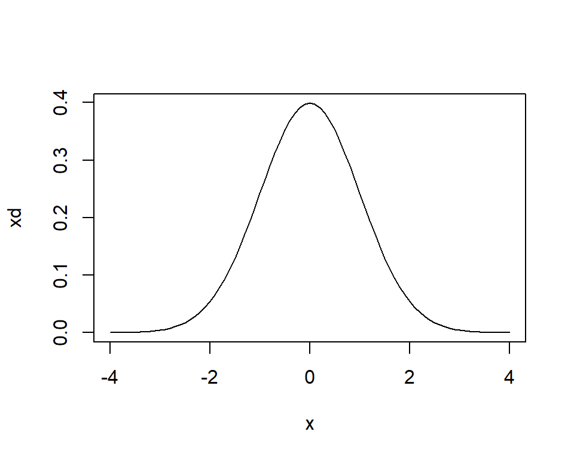

```r
x = seq(from=-4, to=4, by=0.1)
xd = dnorm(x)
plot(x,xd,type="l")
```

Wir können das gleiche auch mit der Verteilungsfunktion machen:

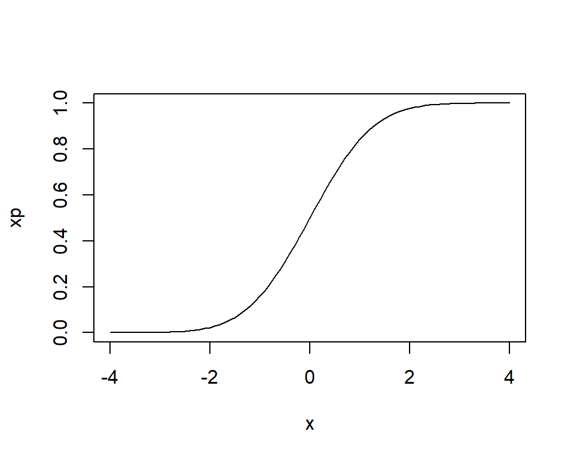

```r
xp = pnorm(x)
plot(x,xp,type="l")
```

Zurück zu unserer Übung: Wir können die **cumsum**-Funktion benutzen um die kumulative Summe zu berechnen. Diese kann dann benutzt werden um den Random Walk-Prozess zu generieren wie in Übung 1. Wir können die Ergebnisse auch plotten.

```r
xr
```

```
 [1] -1.6612888 -1.0185564  0.4134934  1.1836685  0.7083777  1.4639746
 [7]  0.3010297  0.3706394 -1.0007102 -0.8665899
```

```r
xcs = cumsum(xr)
xcs
```

```
 [1] -1.6612888 -2.6798452 -2.2663518 -1.0826834 -0.3743056  1.0896689
 [7]  1.3906986  1.7613380  0.7606278 -0.1059621
```

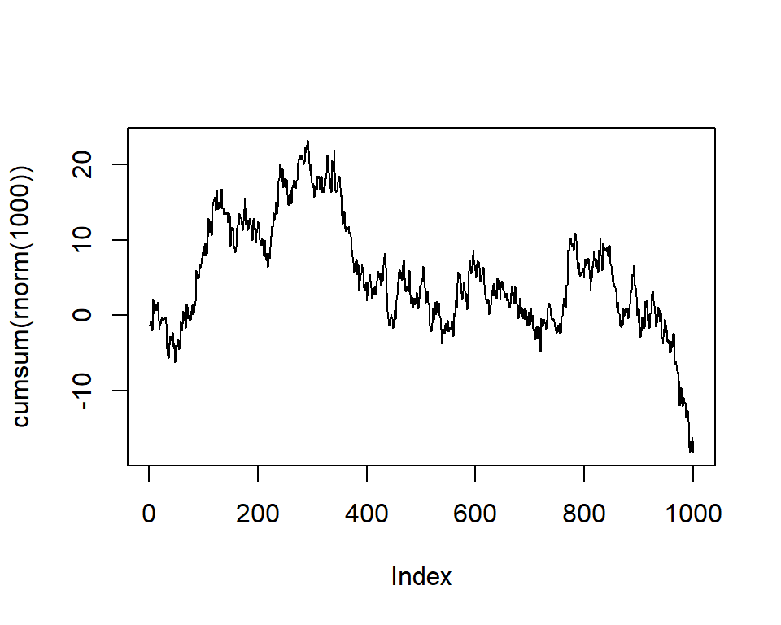

```r
plot(cumsum(rnorm(1000)),type='l')
```

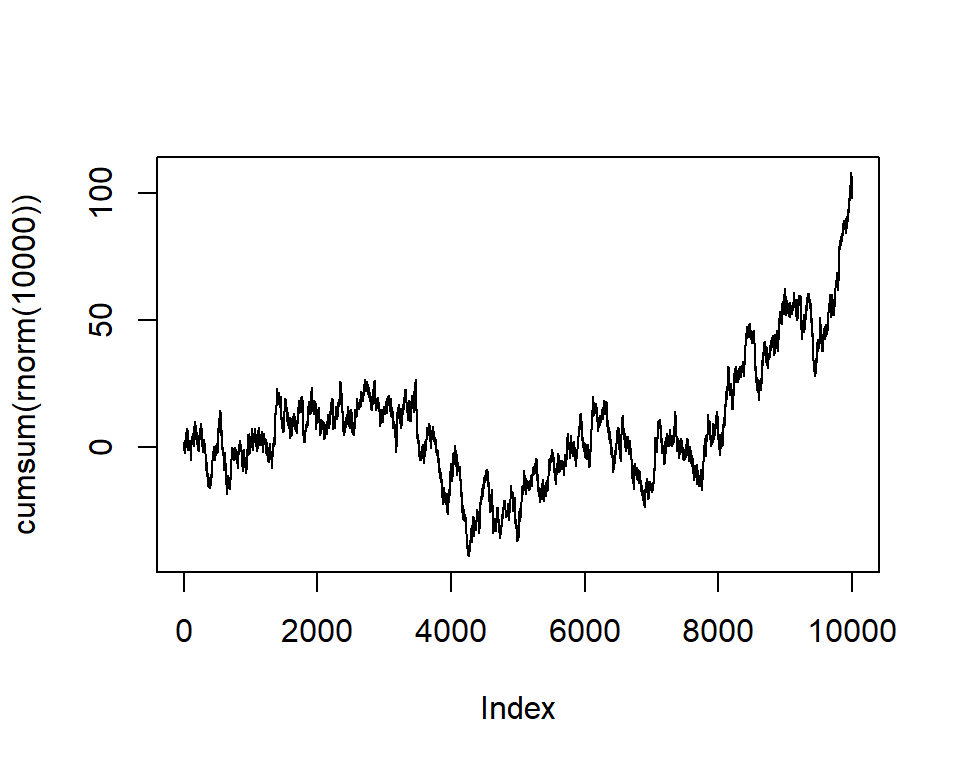

```r
plot(cumsum(rnorm(10000)),type='l')
```

#### *Übung 1*

**Übung 1**

*Steigt der Random Walk Prozess generell an, fällt er ab oder hat er keine dominante Richtung?*

**Lösung**

Es gibt keine dominante Richtung, der Mittelwert der Innovationen ist 0. Beachte als Beispiel die folgenden drei random walks.

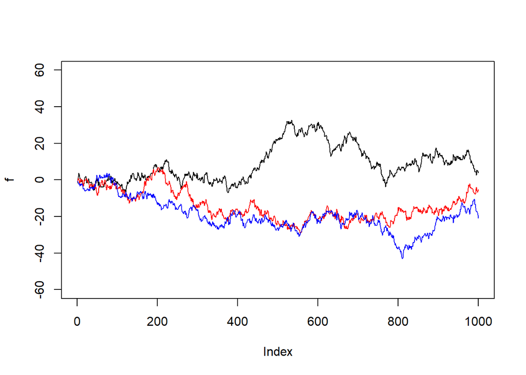

```r
# Generiere und plotte drei unabhängige Realisierungen eines random walk Prozesses.
f = cumsum(rnorm(1000))
g = cumsum(rnorm(1000))
h = cumsum(rnorm(1000))

plot(f, type = "l", ylim=c(-60,60))
lines(g, col = "red")
lines(h, col = "blue")
```

#### *Übung 2*

**Übung 2**

```r
var(cumsum(rnorm(10)))
```

```
[1] 0.6064614
```

```r
var(cumsum(rnorm(100)))
```

```
[1] 14.46846
```

```r
var(cumsum(rnorm(1000)))
```

```
[1] 245.8378
```

```r
var(cumsum(rnorm(10000)))
```

```
[1] 1288.251
```

```r
var(cumsum(rnorm(100000)))
```

```
[1] 12591.44
```

```r
var(cumsum(rnorm(1000000)))
```

```
[1] 54122.79
```

*Erklärt warum ein Random Walk eine Varianz hat, die mit der Zeit zunimmt!*

**Lösung**

Random walk Prozesse können als Summen **unabhängiger** Zufallsvariablen $\epsilon_t, t=1,...n$ gesehen werden. Die Varianz ist per Definition immer positiv. Dadurch nimmt die Varianz der Zufallsvariablen $y_t = \sum_{i=1}^{t} \epsilon_i$ immer mit der Länge der Serie zu. Die empirische Varianz der kompletten Zeitreihe steigt daher ebenfalls mit der Länge der Serie.

## 4 Generierung von AR-Prozessen

Seht Euch die folgende Funktion zur Generierung eines AR-Prozesses an.

```r
generate.ar <- function(n, beta, sd=1)
{
  ar = rnorm(length(beta),0,sd)
  for (t in (length(beta)+1):n) {
    y <- sum(ar[(t-1):(t-length(beta))] * beta) + rnorm(1,0,sd)
    ar = c(ar,y)
  }
  return(ar)
}
```

Die Parameter können wie folgt beschrieben werden:

- `n` beschreibt die Länge der Zeitreihe, die erstellt werden soll
- `beta` ist ein Vektor mit AR-Koeffizienten, wobei `length(beta)` die Ordnung des AR-Prozesses bestimmt
- `sd` repräsentiert die Standardabweichung der normalverteilten Innovationen $\epsilon_i$.

Der folgende Aufruf generiert und plottet einen AR(2)-Prozess mit den Koeffizienten $(0.5,0.2)$

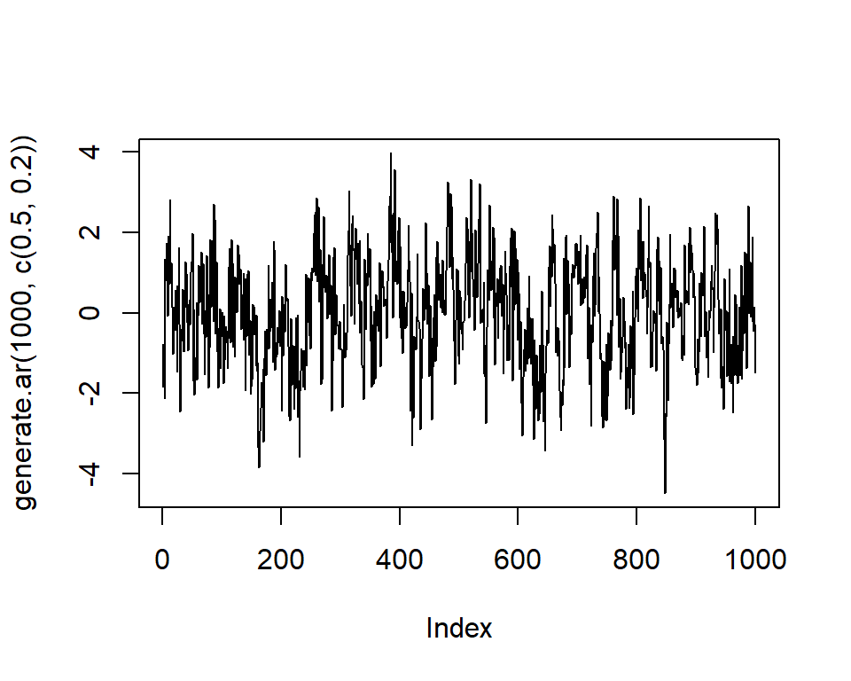

```r
plot(generate.ar(1000, c(0.5,0.2)), type="l")
```

#### *Übung 3*

**Übung 3**

*Welche Werte für `beta` kann man nutzen, um (i) weißes Rauschen (white noise) und (ii) ‘random walk’- Prozesse zu erstellen?*

**Lösung**

Wenn man für `beta` einen Vektor mit nur einer Zahl “0” einsetzt, erhält man einen AR-Prozess mit $\phi_1 = 0$ und damit: $y_t = 0*y_{t-1} + e_t$, also nichts anderes als weißes Rauschen: $y_t = e_t$

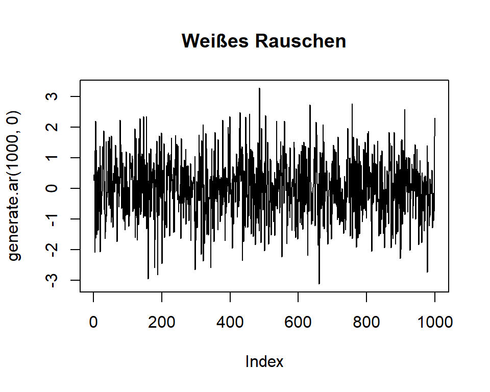

```r
plot(generate.ar(1000, 0), type="l", main="Weißes Rauschen")
```

Wenn man für `beta` einen Vektor mit nur einer Zahl “1” einsetzt, erhält man einen AR-Prozess mit $\phi_1 = 1$ und damit: $y_t = 1*y_{t-1} + e_t$, also nichts anderes als einen ranrom walk: $y_t = y_{t-1} + e_t$

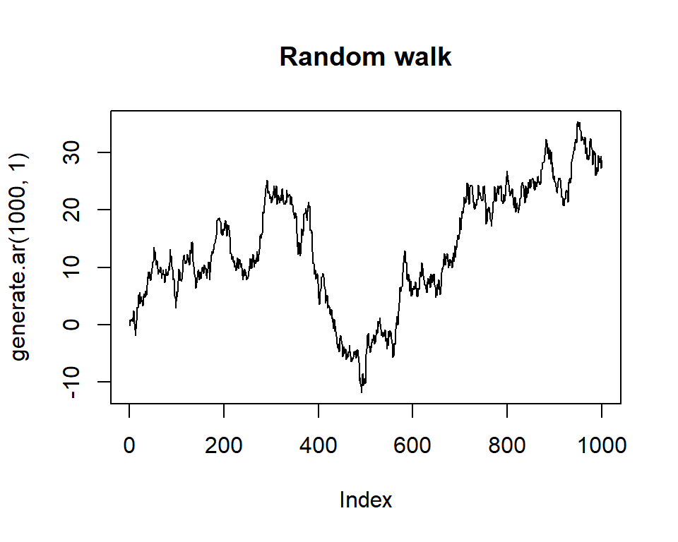

```r
plot(generate.ar(1000, 1), type="l", main="Random walk")
```

#### *Übung 4*

**Übung 4**

*Betrachtet den AR(2) Prozess oben: Steigt seine Varianz mit der Länge an?*

**Lösung**

```r
y <- generate.ar(10000,c(0.5,0.2))

var(y[1:100])
```

```
[1] 1.956102
```

```r
var(y[1:200])
```

```
[1] 1.815503
```

```r
var(y[1:500])
```

```
[1] 1.555059
```

```r
var(y[1:1000])
```

```
[1] 1.631525
```

```r
var(y[1:5000])
```

```
[1] 1.681873
```

```r
var(y[1:10000])
```

```
[1] 1.658259
```

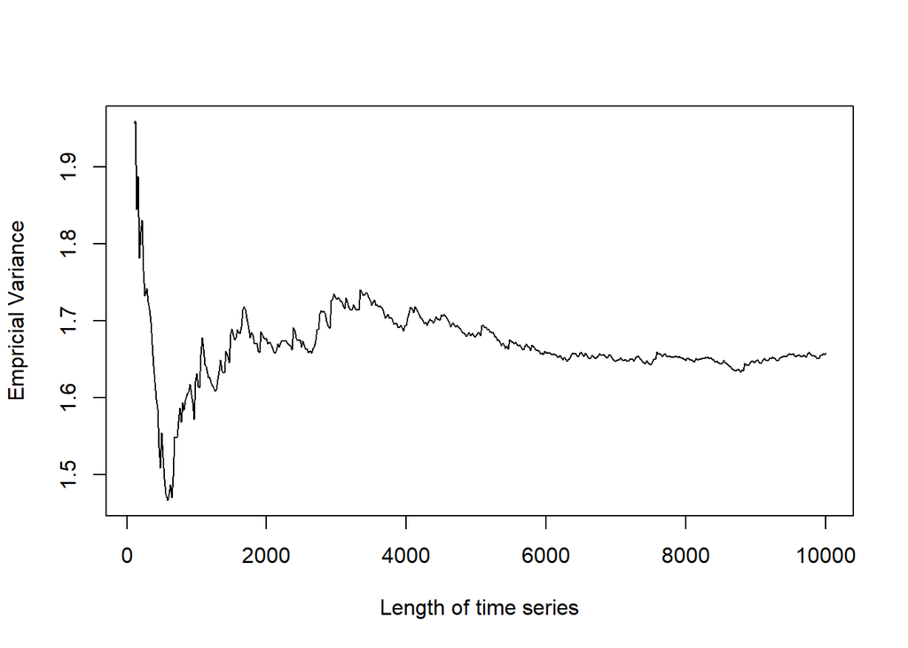

```r
ts.length = seq(from = 100,to=10000,by = 20)
ts.var = sapply(ts.length,function(i) {var(y[1:i])})
plot(x=ts.length, y=ts.var, type="l", ylab="Empricial Variance", xlab="Length of time series")
```

Nein. Prozesse mit dieser Eigenschaft werden auch manchmal als “(ko)-varianzstationär” bezeichnet, was bedeutet, dass die Variabilität des Prozesses nicht von $t$ abhängt.

#### *Übung 5*

**Übung 5**

Die R-Funktionen `acf()` und `pacf()` erstellen einen Plot der empirischen (partiellen) Autokorrelation einer gegebenen Zeitreihe (siehe `?acf` und `?pacf` für mehr Details).

*Generiert einige AR-Prozesse unterschiedlicher Ordnung und probiert verschiedenene Werte für `beta`. Plottet sowohl Autokorrelation als auch partielle Autokorrelation und beschreibt wie diese sich mit unterschiedlicher Länge und unterschiedlichen Parameterwerten verändern.*

**Beachte:** Die Koeffizienten müssen vorsichtig gewählt werden um valide Prozesse zu generieren. Als Faustregel kann die Formel genutzt werden $\sum |\beta_i| < 1$.

**Lösung**

**Beispiel 1: AR1 mit beta = 0.1:**

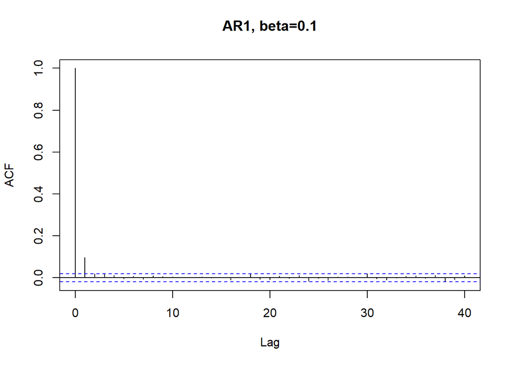

```r
y <- generate.ar(10000,c(0.1))
acf(y, main="AR1, beta=0.1")
```

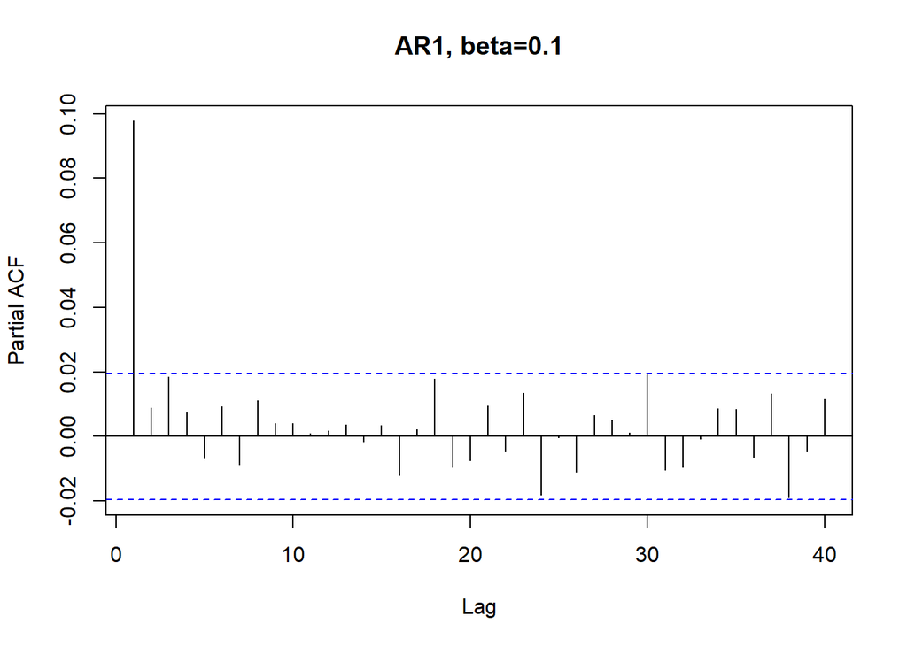

```r
pacf(y, main="AR1, beta=0.1")
```

**Beispiel 2: AR1 mit beta = 0.9:**

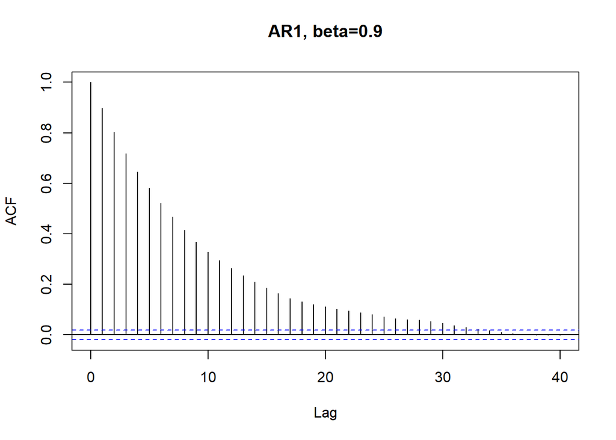

```r
y <- generate.ar(10000,c(0.9))
acf(y, main="AR1, beta=0.9")
```

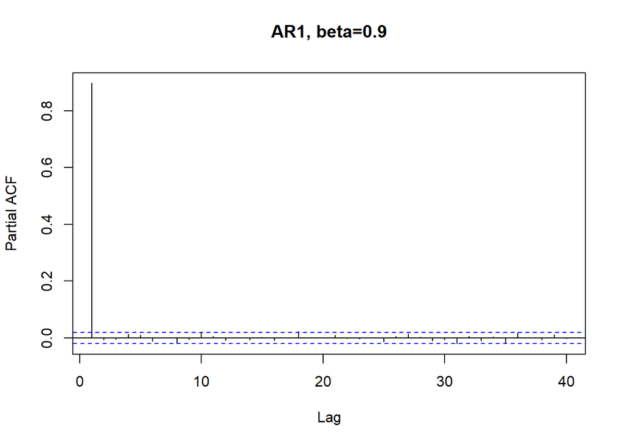

```r
pacf(y, main="AR1, beta=0.9")
```

**Beispiel 3: AR5 mit beta = c(0.05,0.05,0.05,0.05,0.05):**

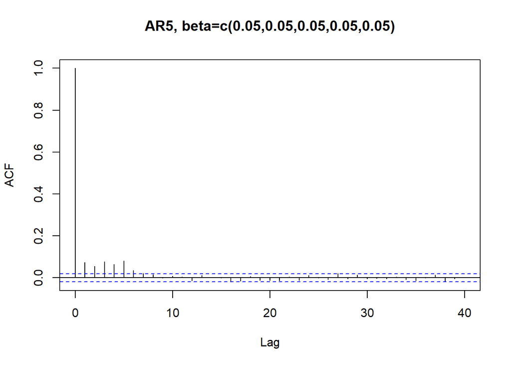

```r
y <- generate.ar(10000,c(0.05,0.05,0.05,0.05,0.05))
acf(y, main="AR5, beta=c(0.05,0.05,0.05,0.05,0.05)")
```

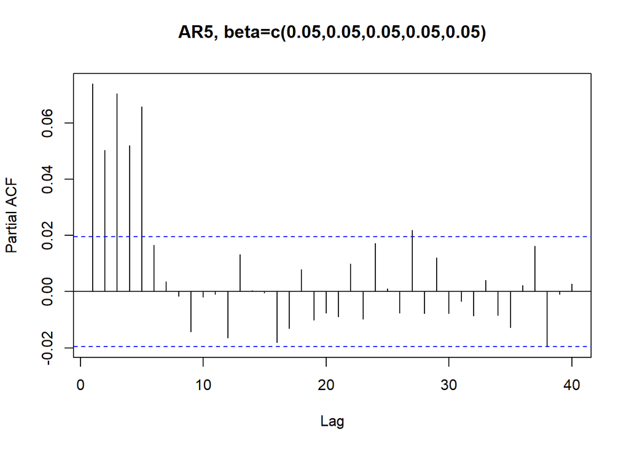

```r
pacf(y, main="AR5, beta=c(0.05,0.05,0.05,0.05,0.05)")
```

**Beispiel 4: AR5 mit beta = c(0.3,0.2,0.2,0.1,0.1):**

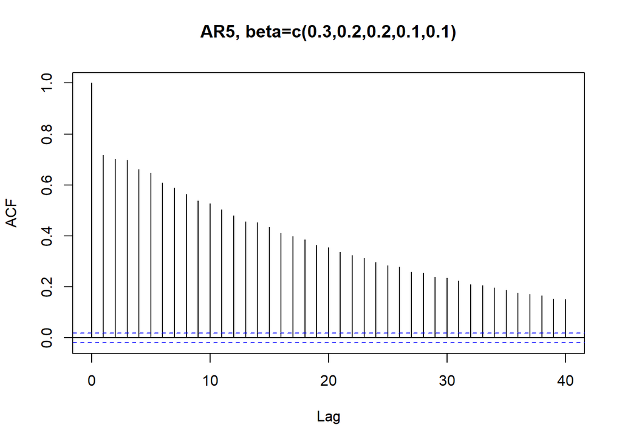

```r
y <- generate.ar(10000,c(0.3,0.2,0.2,0.1,0.1))
acf(y, main="AR5, beta=c(0.3,0.2,0.2,0.1,0.1)")
```

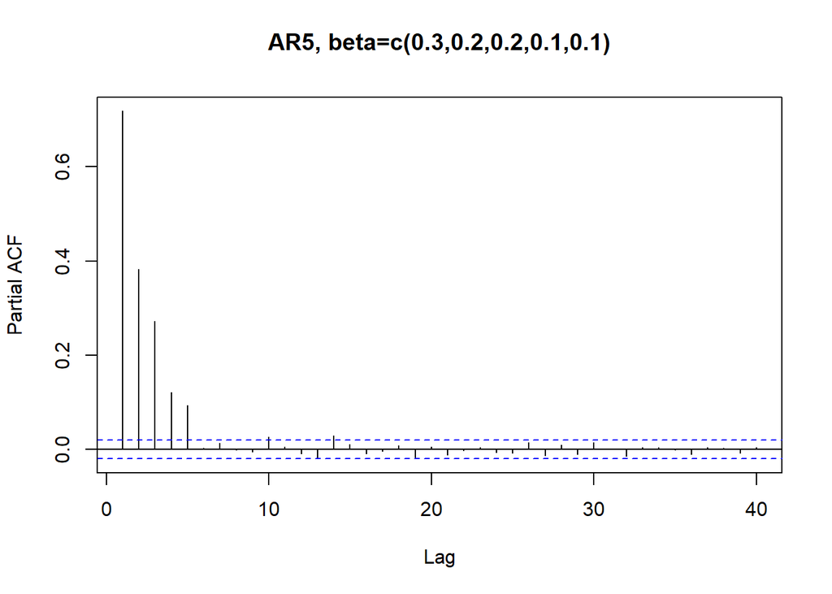

```r
pacf(y, main="AR5, beta=c(0.3,0.2,0.2,0.1,0.1)")
```

**Was können wir daraus lernen?**

Die Ordnung eines AR-Prozesses beeinflusst die Autkorrelation und partielle Autokorrelation. Partielle Autokorrelation ist für gewöhnlich signifikant bis zu einer Anzahl an Lags gleich der AR-Ordnung. Die AR-Koeffizienten selbst beeinflusen zwar die Werte und Länge der ACF sowie die Werte der PACF, aber nicht die Länge der PACF.